# Assignment 1: Data visualization

Tamas Nagy

# Task 1: Climbing expeditions

The 2020-09-22 TidyTueday datasets are about climbing expeditions. From the three datasets, use the “expeditions”. https://github.com/rfordatascience/tidytuesday/blob/master/data/2020/2020-09-22/ Reproduce the plot below!

- Use the “datasets/expedition” dataset, which is a summarized version of the above mentioned dataset. `expedition <- read_csv("datasets/expeditions.csv")`
- The bar colors use the viridis palette and the light theme.

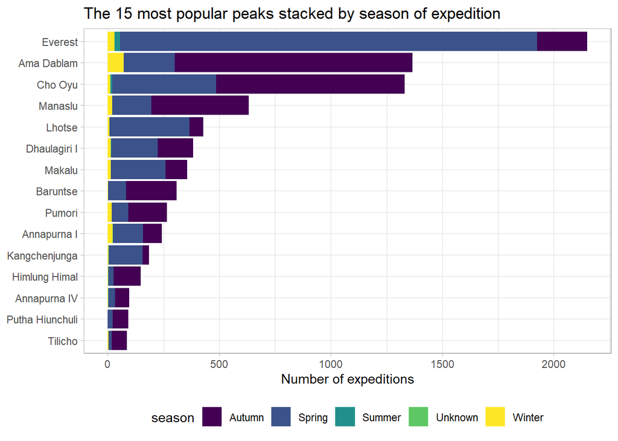

```r
# We need to do some data wrangling first, which is not part of the current task
# expedition_raw <-
#     read_csv('https://raw.githubusercontent.com/rfordatascience/tidytuesday/master/data/2020/2020-09-22/expeditions.csv')
#
# expedition <-
#     expedition_raw %>%
#     # Lump together less frequent peak names, and remove those
#     mutate(peak_name = fct_lump(peak_name, 15)) %>%
#     filter(peak_name != "Other") %>%
#     # Count the number of peak names by season
#     count(peak_name, season, sort = TRUE)
#
# write_csv(expedition, "datasets/expeditions.csv")

expedition <- read_csv(here::here("datasets/expeditions.csv"))

expedition  %>%
    # Reorder the peak names by the number of all climbs
    # You don't have to know this step yet
    mutate(peak_name =  fct_reorder(peak_name, n, .fun = sum)) %>%
    ggplot() +
    aes(y = peak_name, x = n, fill = season) +
    geom_col() +
    theme_light() +
    labs(title = "The 15 most popular peaks stacked by season of expedition",
         y = NULL,
         x = "Number of expeditions") +
    scale_fill_viridis_d(option = "viridis") +
    theme(legend.position = "bottom")
```

# Task 2: PhDs awarded

The 2019-02-19 TidyTueday dataset is about phd-s awarded by year and field. https://github.com/rfordatascience/tidytuesday/tree/master/data/2019/2019-02-19 Reproduce the plot below!

- Use the “datasets/phd” dataset, which is a summarized version of the above mentioned dataset. `phd <- read_csv("datasets/phd.csv")`
- To make the x axis breaks pretty, use `scales::pretty_breaks()`, to make the y axis labels comma formatted, use `scales::comma_format()`.
- The line size is 1.2, the colors are from the brewer “Dark2” palette. The theme is set to minimal.

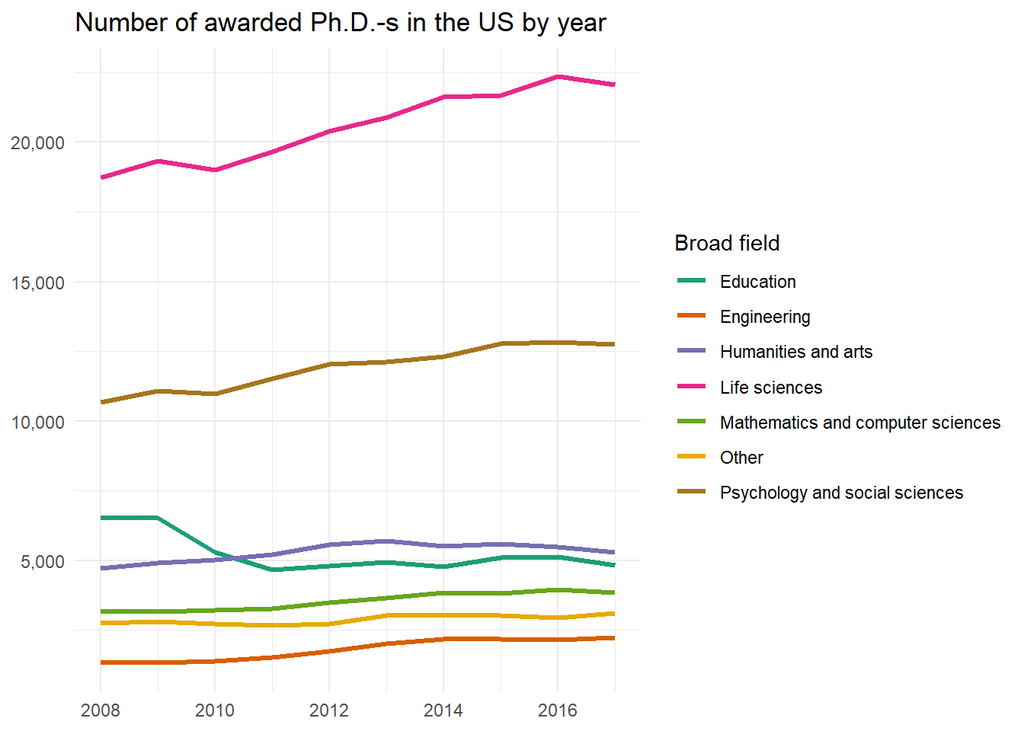

```r
# We need to do some data wrangling first, which is not part of the current task
# phd_raw <- read_csv("https://raw.githubusercontent.com/rfordatascience/tidytuesday/master/data/2019/2019-02-19/phd_by_field.csv")
#
# phd <-
#     phd %>%
#     count(broad_field, year, wt = n_phds)
#
# write_csv(phd, "datasets/phd.csv")

phd <- read_csv(here::here("datasets/phd.csv"))

phd %>%
  ggplot() +
  aes(x = year, y = n, color = broad_field, group = broad_field) +
  geom_line(size = 1.2) +
  scale_color_brewer(palette = "Dark2") +
  theme_minimal() +
  scale_y_continuous(labels = scales::comma_format()) +
  scale_x_continuous(breaks = scales::pretty_breaks()) +
  labs(title = "Number of awarded Ph.D.-s in the US by year",
       x = NULL, y = NULL,
       color = "Broad field")
```

# Task 3: Commute in the US

The 2019-11-05 TidyTueday dataset is about commuting to work in each city in the US by bike or on foot. https://github.com/rfordatascience/tidytuesday/tree/master/data/2019/2019-11-05 Reproduce the plot below!

- Use the “datasets/commute” dataset, which is a summarized version of the above mentioned dataset. `commute <- read_csv("datasets/commute")`
- Both axis scales are log transformed and the labels comma formatted, using `scales::comma_format()`
- The point size is 2. The theme is set to light. Use the default color palette.

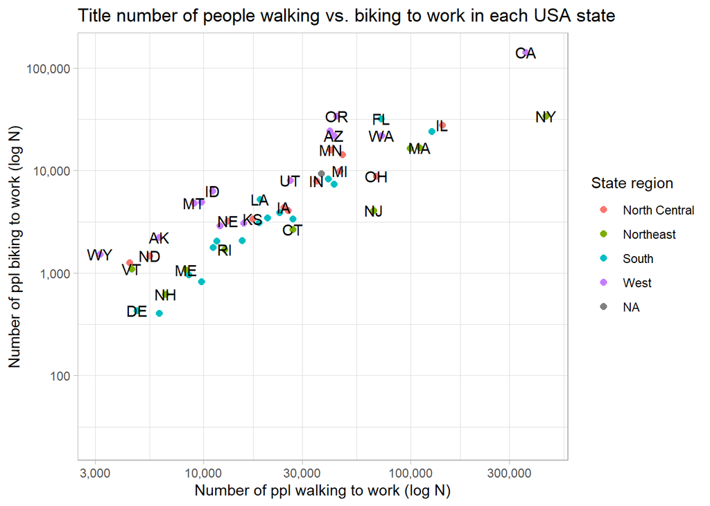

```r
# We need to do some data wrangling first, which is not part of the current task
# commute_raw <- read_csv("https://raw.githubusercontent.com/rfordatascience/tidytuesday/master/data/2019/2019-11-05/commute.csv")
#
# commute <-
#     commute_raw %>%
#     group_by(state_region, state, state_abb, mode) %>%
#     tally(wt = n) %>%
#     pivot_wider(names_from = "mode", values_from = "n")
#
# write_csv(commute, "datasets/commute")

commute <- read_csv(here::here("datasets/commute"))

commute %>%
    ggplot() +
    aes(x = Walk, y = Bike, label = state_abb) +
    scale_x_log10(labels = scales::comma_format()) +
    scale_y_log10(labels = scales::comma_format()) +
    geom_point(aes(color = state_region), size = 2) +
    geom_text(check_overlap = TRUE) +
    theme_light() +
    labs(
        title = "Title number of people walking vs. biking to work in each USA state",
        color = "State region",
        x = "Number of ppl walking to work (log N)",
        y = "Number of ppl biking to work (log N)"
    )
```